# GUSMap_example

Timothy Bilton

14 June 2018

# Code for testing GUSMap

## Example 1: Manuka dataset

This example is a recode of the example given in the README file for the master branch (with a few slight additions).

#### Read in data

```r
## get file paths to Manuka data
MKdata <- Manuka11()
## Convert VCF to RA
RAfile <- VCFtoRA(MKdata$vcf)
```

```
## Processing VCF file: Converting to RA format.
##
## Found 183 samples
## 680 SNPs written
##
## Name of RA file:     Manuka_chr11.vcf.ra.tab
## Location of RA file: C:/Users/Timothy/Documents/Academia/Otago_University/GUSMap/
```

```r
## read in the RA fill
RAdata <- readRA(RAfile, gform = "reference")
```

The above functions are merely to read in data. *VCFtoRA* is probably the slowest and can take 5-10 minutes for a large datasets (e.g. 400,000 SNPs).

#### Create a mapping population

```r
MK_fs <- makeFS(RAdata, pedfile=MKdata$ped)
```

```
## -------------
## Processing Data.
##
## Filtering criteria for removing SNPs:
## Minor allele frequency (MAF) < 0.05
## Percentage of missing genotypes > 20%
## Distance for binning SNPs <= 0 bp
## Read depth associated with at least one parental genotype <= 5
## P-value for segregation test < 0.01%
##
## Processing Family Manuka.
##
## -------------
## Summary:
##
## Number of SNPs remaining after filtering: 680
## Both-informative (BI): 116
## Maternal-informative (MI): 294
## Paternal-informative (PI): 270
## Number of progeny: 177
```

The above function processes (including some filtering) the RA file into a format required for a full-sib family. There are a whole bunch of things going inside this function.

#### Compute pairwise rf’s

Now, we need to compute all the pairwise recombination fraction estimates between all pairs of SNPs.

```r
MK_fs$rf_2pt(nClust=3)
```

```
##
## Computing 2-point recombination fraction estimates ...
## Paternal informative SNPs
## Maternal informative SNPs
## Both informative SNPs
## Paternal informative vs Both informative
## Maternal informative vs Both informative
## Maternal informative vs Paternal informative
```

The above function is very slow because it is taking each pair of SNPs and computing a likelihood to get a point estimate. *nClust* argument specifies the number of cores to use with the parallelization within the function using the *foreach* R package.

Heatmaps of these estimates are

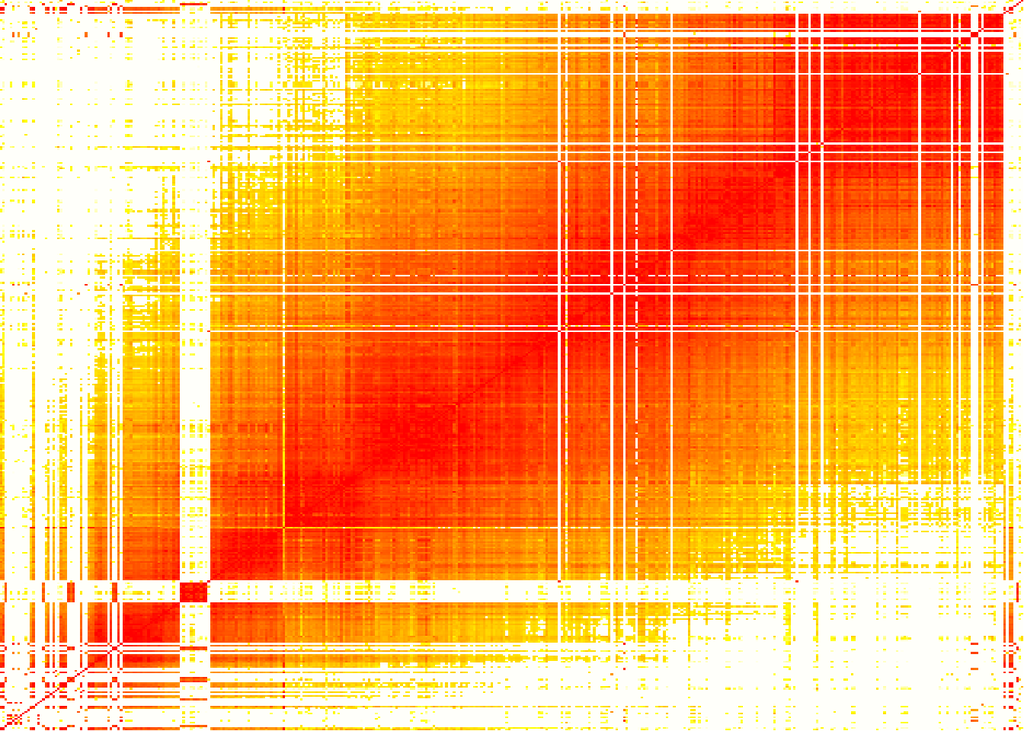

```r
MK_fs$plotChr(parent = "maternal")
```

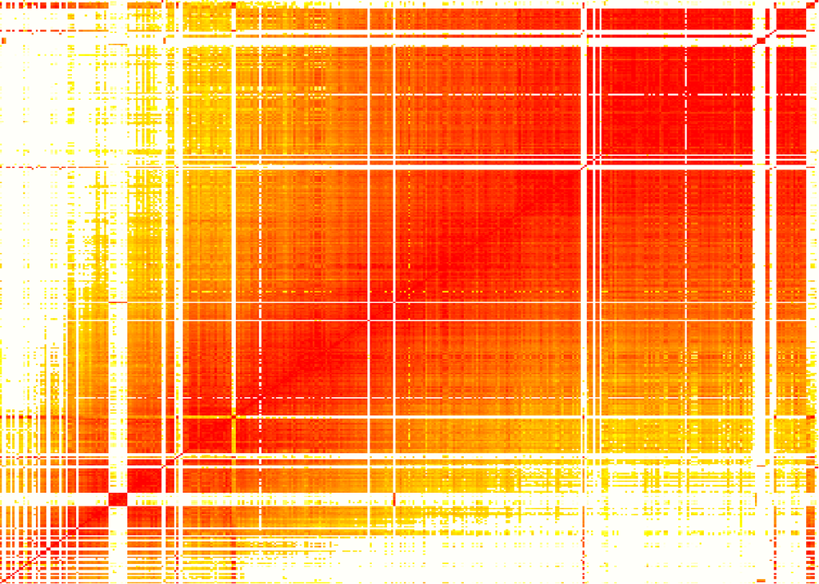

```r
MK_fs$plotChr(parent = "paternal")
```

#### Mask SNPs

The code below is just to mask some SNPs to get the same results as in the paper by Bilton et al. (2018). Heatmaps are again produced to check output.

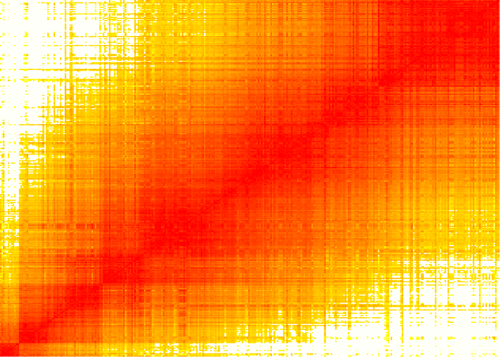

```r
##Want to mask the SNPs know to be bad
badSnps <- rep(FALSE, MK_fs$.__enclos_env__$private$nSnps)
badSnps[c(3:14,16,18:23,25:27,29,33:35,39:42,44,46:49,
   53,58:60,63,65:67,69:74,76,77,85,104,114:129,
   152,162,163,173:180,187:190,206:208,210,212,213,
   216,228,272,285,286,298,304,314,318,320,342,344,345,
   354,358,370,373,380,389,390,397,408,411,421,427,
   437,446,469,493,498:500,506,510,516,519,522,531,
   543,553,556,569,582,585,601,617,620,623,628,635,
   636:643,647:650,669:680)] <- TRUE
MK_fs$maskSNP(which(badSnps))
MK_fs$plotChr(parent = "maternal")
```

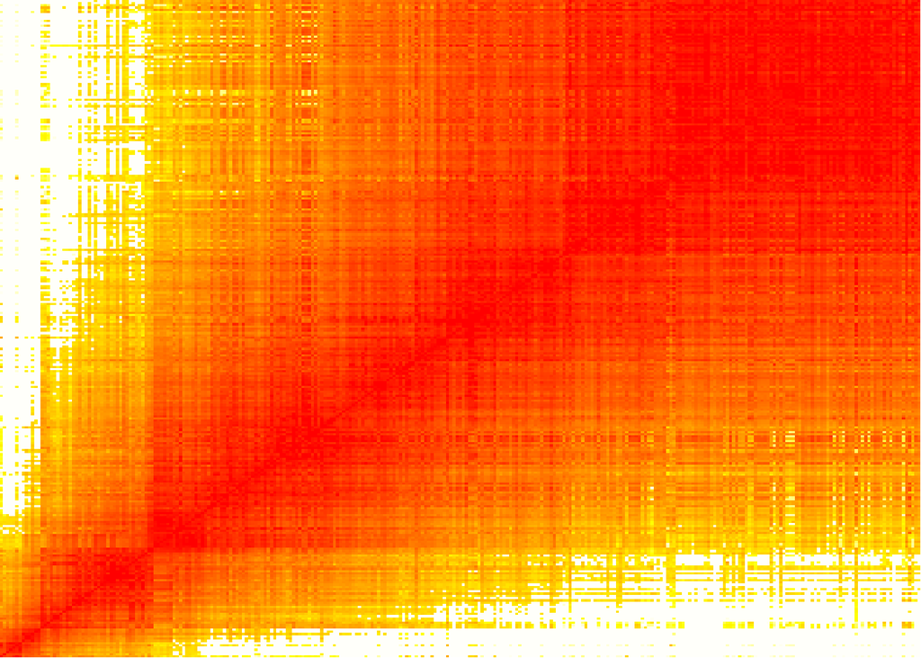

```r
MK_fs$plotChr(parent = "paternal")
```

#### Compute the linkage maps for SNPs on chromosome 11

```r
depth <- MK_fs$.__enclos_env__$private$ref[[1]] + MK_fs$.__enclos_env__$private$alt[[1]]
rd6 <- ((colMeans(depth) > 6) | badSnps)
MK_fs$maskSNP(which(rd6))
## Compute the rf estimates
## using optim
MK_fs$rf_est(method="optim", mapped = FALSE)
```

```
## Computing recombination fractions:
## Chromosome:  11
```

```r
## should be 76.09481
sum(GUSMap:::mfun(MK_fs$.__enclos_env__$private$para$rf_p[[1]],fun = "haldane", centiM = T))
```

```
## [1] 76.09481
```

```r
MK_fs$.__enclos_env__$private$para$ep[[1]]
```

```
## [[1]]
## [1] 0.003167973
```

```r
## should be 0.003167973
######
## using EM algorithm
MK_fs$rf_est(method="EM", mapped = FALSE)
```

```
## Computing recombination fractions:
## Chromosome:  11
```

```r
## should be 76.09481
sum(GUSMap:::mfun(MK_fs$.__enclos_env__$private$para$rf_p[[1]],fun = "haldane", centiM = T))
```

```
## [1] 76.09481
```

```r
## should be 0.003167973
MK_fs$.__enclos_env__$private$para$ep[[1]]
```

```
## [[1]]
## [1] 0.003167973
```

The *MK_fs$rf_est()* is the main function here and is solving the likelihood for a hidden Markov model (HMM). The likelihood is written as C functions and are in the src folder. There is also two different optimization routines:

- Direct maximization: Using the *optim* function in R with the C scripts *likelihoods.c* and *score.c* being called.
- Expectation-Maximization (EM) algorithm. Uses the *em.c* C script.

## Example 2: Large data set:

For a larger dataset, I’ll simulate some ideal data below (for two chromosomes)

```r
noChr=2
nSnps=100
noFam=1
set.seed(5721)
config <- list(sapply(1:noChr, function(x) list(sample(c(1,2,4),size=nSnps, prob=c(1,2,2)/5, replace=T)), simplify=T))
simData <- simFS(1/nSnps,epsilon=0.01,config=config,nInd=200, meanDepth=5, noChr=noChr, seed1=687534, seed2=6772)
```

Again compute the pairwise recombination fraction estimates between all pairs of SNPs.

```r
simData$rf_2pt(nClust=3)
```

```
##
## Computing 2-point recombination fraction estimates ...
## Paternal informative SNPs
## Maternal informative SNPs
## Both informative SNPs
## Paternal informative vs Both informative
## Maternal informative vs Both informative
## Maternal informative vs Paternal informative
```

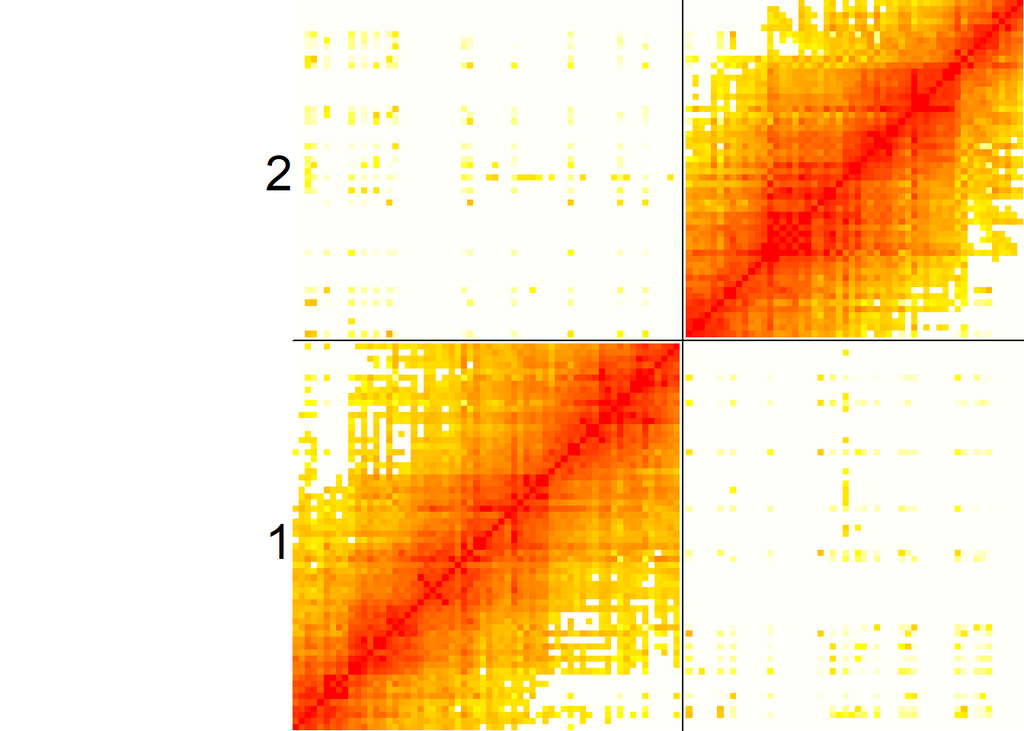

```r
## plot the results
simData$plotChr(parent="maternal")
```

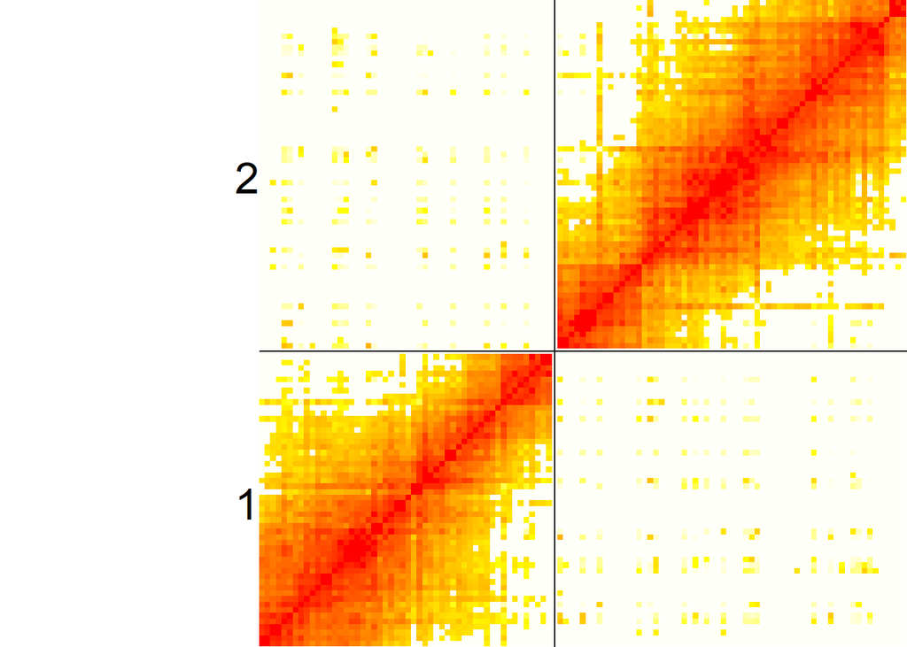

```r
simData$plotChr(parent="paternal")
```

Solve the likelihood for the hidden Markov model (HMM) and get recombination fraction estimates

```r
simData$rf_est(method="optim", mapped = FALSE)
```

```
## Computing recombination fractions:
## Chromosome:  1
## Chromosome:  2
```

```r
## Chromosome 1
## Should be 98.41231
sum(GUSMap:::mfun(simData$.__enclos_env__$private$para$rf_p[[1]],fun = "haldane", centiM = T))
```

```
## [1] 100.048
```

```r
## 0.01010545
simData$.__enclos_env__$private$para$ep[[1]]                 ## 0.01010545
```

```
## [[1]]
## [1] 0.01046925
```

```r
## Chromosome 2
## Should be 103.2207
sum(GUSMap:::mfun(simData$.__enclos_env__$private$para$rf_p[[2]],fun = "haldane", centiM = T))
```

```
## [1] 103.5512
```

```r
## 0.009815709
simData$.__enclos_env__$private$para$ep[[2]]
```

```
## [[1]]
## [1] 0.009672618
```